# STAT 361 - RECITATION 6

# Topic : Variance Reduction

### İrem Tanrıverdi, iremt@metu.edu.tr

### Date: 21.04.2022

## REVIEW

Suppose f(x) is any function that has an integrate on the closed interval [a,b], then the integral $\int_a^bf\left(x\right)\ dx$ gives the area of the region is bounded by (a,b).

Let g(x) is simple Monte Carlo estimator.

Then,

Let $u_1,u_2, u_3,...,u_n$ be independent uniform random variables on the interval [a,b] then from the uniform distribution:

$f\left(u\right)\ =\ \frac{1}{b-a}$ so that $E\left[f\left(u\right)\right]\ =\ \int_a^bf\left(u\right)\cdot\frac{1}{b-a}du$. where f(u)=g(x) Monte carlo estimator.

$E\left[f\left(u\right)\right]\ =\ \int_a^bf\left(u\right)\cdot\frac{1}{b-a}du$. How we can obtain Monte Carlo estimator using its expected value? This defines the original integral $\int_a^bf\left(u\right)\ du$ = $\int_a^bg(x)\ dx$ which can be approximated by multiplying the a sample mean E(f(u))=E(g(x)), by $\left(b-a\right)$.

To summarize, the simple Monte Carlo estimator of the integral $\theta= \int_a^b g(x)dx$ is computed as follows;

1. Generate $𝑋_1,...,𝑋_m$ i.i.d. from Uniform(a,b).
2. Compute $\bar g(x)= \frac{1}{m} g(x_1)$.--> Mean of Monte Carlo estimator. (m is number of obsvs.)
3. $\hat \theta = (b-a)\bar{g(x)}$ --> Estimate of integral.

## 1. Variance

We know that $\hat \theta = (b-a)\bar{g(x)}$. Then, take expectation of both side;

$$ E[\hat \theta] = E[(b-a)\bar{g(x)}] $$$$ E[\hat \theta] = (b-a)E[\bar{g(x)}] $$

Since its unbiased estimator;

$$ \theta = (b-a)g(x) $$

Then, obtain g(x)--> The sample mean g(𝑋) has expected value

$$ g(x)=\frac{\theta}{(b-a)} $$

and,

$$ Var(\bar{g(x)}) = \frac {Var(g(x))}{m} $$

Since $\hat \theta$ is unbiased estimator for $\theta$; $E[\hat \theta] = \theta$

$$ Var[\hat \theta] =(b-a)^2 Var(\bar{g(x)}) = (b-a)^2 \frac {Var(g(x))}{m} $$

The central limit theorem asserts that as $m → \infty$, the distribution of $\hat \theta$;

$$ \hat \theta \sim N(\theta,\ (b-a)^2 Var(g(x))/m) $$

## 2. Efficiency

Remember (from STAT 303 course) that for an unbiased estimator, efficiency indicates how much its precision is lower than the theoretical limit of precision provided by the Cramer-Rao inequality. A measure of efficiency is the ratio of the theoretically minimal variance to the actual variance of the estimator. This measure falls between 0 and 1. An estimator with efficiency 1.0 is said to be an "efficient estimator".

Let $\hat \theta_1$ and $\hat \theta_2$ be two estimators of $\theta$, we can say that $\hat \theta_1$ is more efficient than $\hat \theta_1$ if;

$$ \frac{Var(\hat \theta_1)}{Var(\hat \theta_2)} < 1 $$

## 3. Variance Reduction

In the theory of Monte Carlo methods, variance reduction is a procedure used to increase the precision of the estimates that can be obtained for a given simulation. Every output random variable from the simulation is associated with a variance which limits the precision of the simulation results. In order to make a simulation statistically efficient, namely to obtain a greater precision and smaller confidence intervals for the output random variable of interest, variance reduction techniques can be used. The main ones are common random numbers, antithetic variates, control variates, importance sampling, stratified sampling, moment matching, conditional Monte Carlo, etc,.

Monte Carlo integration is used to estimate functions of $\theta$. Now let learn the approaches to reduce the variance in the sample mean estimator, $\hat \theta$.

By comparing variances of different estimators for $\theta$ , the most efficient one can be obtained and the percent reduction in variance by using the more efficient parameter can be found by

$$ 100* \frac{Var(\hat \theta_1)- Var(\hat \theta_2)}{Var(\hat \theta_1)} $$

Besides,

$$ Var[\hat \theta] = (b-a)^2 \frac {Var(g(x))}{m} $$

increasing m, the number of replicates reduces the variance. However, to keep standard error small enough (about 0.0001), approximately 10000 replicates are needed. Thus, although variance can always be reduced by increasing the number of Monte Carlo replicates, the computational cost is high. Other methods for reducing the variance can be applied that are less computationally expensive than simply increasing the number of replicates.

## 3.1. Antithetic Variables

### A little reminder!

If X and Y are independent, then var(X + Y ) = var(X) + var(Y ). If they are not independent the covariance enters. Letting $\mu_x , \mu_y$ denote the means of X and Y , we have

$$ Var(X +Y) = E[(X +Y)^2]−(\mu_x + \mu_y)^2 $$$$ = E[X^2]−μ_x^2 +E[Y^2]−μ_y^2 +2(E[XY]−\mu_x \mu_y) $$$$ = var(X) + var(Y ) + 2cov(X, Y) $$

The covariance is cov(X, Y ) = $ρ_{X,Y} σ_X σ_Y$ and ρ lies between −1 and 1. If ρ is negative the variance of X + Y is smaller than the sum of their variances. Antithetic variables take advantage of this fact.

In statistics, the antithetic variates method is a variance reduction technique used in Monte Carlo methods. Considering that the error in the simulated signal (using Monte Carlo methods) has a one-over square root convergence, a very large number of sample paths is required to obtain an accurate result. The antithetic variates method reduces the variance of the simulation results.

**Definition:** Random variables X, Y on the same probability space are **antithetic** if they have the same distribution and their covariance is negative. It would be advantageous (in the sense that the variance would be reduced) if X and Y rather than being independent were negatively correlated.

Suppose we want to compute $\theta_1$ = E[X] and we can find another random variable Y such that X, Y is an antithetic pair. So E[Y] is equal to $\theta_2$. Our Monte Carlo algorithm is as follows. We generate n indendent samples $u_1,u_2,...,u_n$ from the probability space. Our estimator for $\theta$ is then;

$$ \hat \theta = \frac{\hat \theta_1 + \hat \theta_2}{2} $$

### How can we arrange 𝑋 and Y negatively correlated?

We know that X and Y are functions of m random numbers;

$$ X = h(U_1, U_2,...,U_m),\ where\ U \sim Uniform(0, 1) $$$$ Y = h(1-U_1, 1-U_2,...,1-U_m),\ where\ 1-U \sim Uniform(0, 1) $$$$ Cov(U,1−U)= V(U)=−1/12 <0 $$

In addition, since U and 1-U are negatively correlated, we can hope that X and Y are also negatively correlated, and indeed that result can be proved in the special case where the function h is a monotone (either increasing or decreasing) function of each of its coordinates.

**To summarize, in order to reduce variance by antithetic variables, out of m replicates, m/2 of them should be generated from U and other half should be generated from 1-U to satisfy the negative correlation.**

## QUESTIONS

### Q1) EXERCISE FROM THE BOOK

### Exercise 5.3 (page 150)

Compute a Monte Carlo estimate $\theta$ of

$$ \theta = \int_0^{0.5} e^{-x} dx $$

After estimate the $\theta$ using Uniform distribution calculate the variance of $\hat \theta$. Then, find another Monte Carlo estimator $\theta^*$ by sampling from the exponential distribution. Which of the variances (of $\hat \theta$ and $\theta^*$) is smaller, and which one is more efficient?

Note that

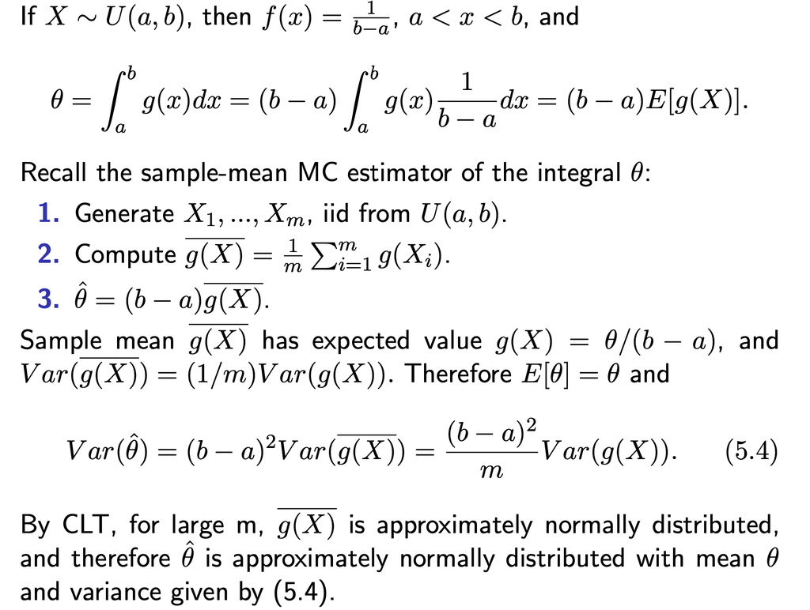

### First we calculate θ̂ by sampling from Uniform(a, b) = Uniform(0, 0.5)

```r
# Step 1: Define f(X)

f <- function(x) exp(-x)


# Step 2: Generate x1,...,xn  iid Uniform(min=a, max=b)

n=10^4
a <- 0; b <- 0.5

x <- runif(n= n, min= a, max= b)


# Step 3: Compute  (b-a)*g(Xbar)


g.X <- sapply(x, f)

g.Xbar = mean(sapply(x ,f))

theta.hat <-  (b-a)*g.Xbar

var.theta.hat <- (b-a)^2 * var(g.X)

#OR

var.theta.hat <- (b-a)^2 * (mean(sapply(x,f)^2) - (mean(sapply(x, f)))^2) # Var(x) = E(X^2) - E(x)^2


cat("Theta hat is ", theta.hat, ", and the variance is ", var.theta.hat, ".")
```

```
Theta hat is  0.3926643 , and the variance is  0.0032136 .
```

### Now we calculate $θ^∗$ by sampling from Exp(1).

```r
# Step 1: Define f(X)

f <- function(x) (exp(-x)*(x>0)*(x<0.5))/(exp(-x))


# Step 2: Generate x1,...,xn  iid Exponential rvs

n=10^4
a <- 0; b <- 0.5

x <- rexp(n=n, rate=1)


# Step 3: Compute  (b-a)*g(Xbar)


g.X.star <- sapply(x, f)

g.Xbar.star = mean(sapply(x ,f))

theta.star <-  g.Xbar.star

var.theta.star <- var(g.X.star)



cat("Theta star is ", theta.star, ", and the variance is ", var.theta.star, ".")
```

```
Theta star is  0.3898 , and the variance is  0.2378797 .
```

For the same n, the variance of θ̂ is significantly smaller than the variance of $θ^∗$.

## Find more efficient estimator?

$\hat \theta$ is more efficient than $\hat \theta^*$ if;

$$ \frac{Var(\hat \theta)}{Var(\hat \theta^*)} < 1 $$

```r
ifelse(var.theta.hat / var.theta.star < 1, print("theta.hat is more efficient than theta.star"),
       print("theta.star is more efficient than theta.hat"))
```

```
[1] "theta.hat is more efficient than theta.star"
```

'theta.hat is more efficient than theta.star'

### Q2)

Use Monte Carlo integration with antithetic variables to estimate

$$ \theta = \int_0^3 \frac{e^{-2x}}{1+x^2} + (4x+2)^2 dx $$

Let fist remember how to calculate this integral using Monte Carlo Integration and calculate it's variance.

```r
# Step 1: Define f(X)

f <- function(x) (exp(-2*x)/(1+x^2)) + (4*x+2)^2


# Step 2: Generate x1,...,xn  iid Uniform rvs

n=10^5
a <- 0; b <- 3

x <- runif(n, a, b)


# Step 3: Compute  (b-a)*g(Xbar)


g.X <- sapply(x, f)

g.Xbar = mean(sapply(x ,f))

theta.hat <-  g.Xbar*(b-a)

var.theta.hat <- var(g.X)*(b-a)^2



cat("Theta hat is ", theta.hat, ", and the variance is ", var.theta.hat, ".")
```

```
Theta hat is  228.2108 , and the variance is  28590.6 .
```

### Let use Antithetic Variables and look if this method really reduce the error or not.

**In order to reduce variance by antithetic variables, out of n replicates, n/2 of them should be generated from U and other half should be generated from 1-U to satisfy the negative correlation.**

Let $Z_1 \sim Uniform(a, b)$ with n/2 observations and its mean is $\theta_1$.

Let $Z_2 \sim b - Z_1$ with n/2 observations and its mean is $\theta_2$.

Antithetic variable = $\frac{Z_1 + Z_2}{2}$

$$ \hat \theta = \frac{\hat \theta_1 + \hat \theta_2}{2} $$

Besides,

$$ Var(\frac{Z_1}{2} +\frac{Z_2}{2}) = \frac{var(Z_1) + var(Z_2) + 2cov(Z_1, Z_2)}{4} $$

```r
# Step 1: Define f(X)

f <- function(x) (exp(-2*x)/(1+x^2)) + (4*x+2)^2


# Step 2: Generate x1,...,xn  iid Uniform rvs

n=10^5
a <- 0; b <- 3

x <- runif(n/2, a, b)


# Step 3: Obtain Antithetic variables

z1 <- f(x)
z2 <- f(b-x)

antithetic <- (z1 + z2)/2

# Step 3: Compute  (b-a)*g(Xbar)

theta1 <- mean(z1) * (b-a)
theta2 <- mean(z2) * (b-a)



ant.estimate <- (theta1 + theta2) / 2

#or;


ant.estimate <- mean(antithetic)*(b-a)



cat("Antithetic theta hat is ", ant.estimate,"\n")


var.ant.estimate <- (var(z1)+var(z2)+2*cov(z1,z2)) / 4


# or;

var.ant.estimate <- var(antithetic)


cat("Antithetic variance of theta hat is ", var.ant.estimate)
```

```
Antithetic theta hat is  228.5063
Antithetic variance of theta hat is  119.0082
```

```r
var_reduction = 100 * ((var.theta.hat-var.ant.estimate)/var.theta.hat)
cat("The antithetic variable approach achived",
round(var_reduction,2), "%", "reduction in variance.")
```

```
The antithetic variable approach achived 99.58 % reduction in variance.
```

### Q3)

(Note that $\Gamma(t)= (t-1)!$)

Estimate P(X < 0.3) using Monte Carlo Integration with both classical approcah and Antithetic variables and then calculate the percent variance reduction. Plot that probability.

## Note that:

**In order to reduce variance by antithetic variables, out of n replicates, n/2 of them should be generated from U and other half should be generated from 1-U to satisfy the negative correlation.**

Let $X \sim Uniform(a, b)$ with n/2 observations and its mean is $\theta_1$.

Let $Y \sim b - X$ with n/2 observations and its mean is $\theta_2$.

Antithetic variable = $\frac{X + Y}{2}$

$$ \hat \theta = \frac{\hat \theta_1 + \hat \theta_2}{2} $$

Besides,

$$ Var(\frac{X}{2} +\frac{Y}{2}) = \frac{var(X) + var(Y) + 2cov(X, Y)}{4} $$

```r
library(tidyverse)
library(scales)


# Step 1: Define f(X)

set.seed(1234)

beta_dist <- function(x, alpha, beta){factorial(alpha+beta-1)/
                                      (factorial(alpha-1)*factorial(beta-1))*x^(alpha-1)*(1-x)^(beta-1)}



# Step 2: Generate iid Uniform rvs x ~ Uniform and y ~ 1-Uniform

n <-10^4
alpha <- 2
beta <- 3

a <- 0
b <- 0.3

u = runif(n/2, a, b)
x = u
y = b - u


# Step 3: Compute  estimate; g(Xbar)

beta_dist_x = beta_dist(x, alpha, beta) # used estimate for classical approach
beta_dist_y = beta_dist(y, alpha, beta)

antithetic <- (beta_dist_x + beta_dist_y)/2


# Estimate

beta_dist_estimate_x = mean(beta_dist(x, alpha, beta))*(b-a) # estimate with classical approach
beta_dist_estimate_y = mean(beta_dist(y, alpha, beta))*(b-a)

beta_dist_ant_estimate = mean(antithetic)*(b-a) # estimate with antithetic approach
# beta_dist_ant_estimate =(beta_dist_estimate_x+beta_dist_estimate_y)*(b-a)

cat("Estimate with classical approcah;", beta_dist_estimate_x, "\n",
   "Estimate with antithetic approcah;", beta_dist_ant_estimate, "\n",
   "Real Probability value;", pbeta(0.3, 2,3))
```

```
Estimate with classical approcah; 0.3491849
 Estimate with antithetic approcah; 0.3484141
 Real Probability value; 0.3483
```

```r
Variance_classical = var(beta_dist_x) # variance of classical approach

Variance_ant = var(antithetic) # variance of classical approach

cat("Reduction in Variance is:",percent((Variance_ant - Variance_classical ) / Variance_classical))
```

```
Reduction in Variance is: -94%
```

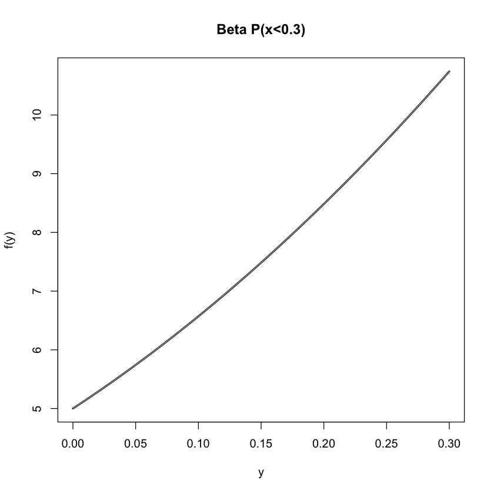

```r
y <- seq(a, b,0.001)
plot(y, f(y), type = "l", lwd = 2.5, main="Beta P(x<0.3)")
lines(y,f(y), col = 'grey')
```

### Q4) EXERCISE FROM THE BOOK

### Exercise 5.9 (page 150)

The Rayleigh density is;

$$ f(x) = \frac{x}{\sigma^2} e^{\frac{-x^2}{2\sigma^2}} $$

and then obtain estimate for integral below both using classical approach and antithetic approach. What is the percent reduction in variance of classical approach compared with $\frac{X1+X2}{2}$ antithetic variables for independent X1, X2?

$$ \theta = \int_0^{\infty} \frac{x}{\sigma^2} e^{\frac{-x^2}{2\sigma^2}} dx $$

Remember that for antithetic variables;

$$ X = h(U_1, U_2,...,U_m),\ where\ U \sim Uniform(0, 1) $$$$ Y = h(1-U_1, 1-U_2,...,1-U_m),\ where\ 1-U \sim Uniform(0, 1) $$

Antithetic variable for estimate; $\frac{X + Y}{2}$

$$ E(X) =\theta_1 \\ E(Y) =\theta_2 $$$$ \hat \theta = \frac{\hat \theta_1 + \hat \theta_2}{2} $$

```r
library(tidyverse)
library(scales)


# Step 1: Define f(X)

set.seed(1234)

rayleigh_dist <- function(x, sigma){ (x/sigma^2) * exp(-x^2)/(2*sigma^2)}



# Step 2: Generate iid Uniform rvs x ~ Uniform and y ~ 1-Uniform

n <-10^4
sigma <-3

u = runif(n)
x = u
y = 1 - u


# Step 3: Compute  estimate; g(Xbar)

ray_dist_x = rayleigh_dist(x, sigma) # used estimate for classical approach
ray_dist_y = rayleigh_dist(y, sigma)

antithetic <- (ray_dist_x + ray_dist_y)/2 # used estimate for antithetic approach

# Estimate

ray_dist_estimate = mean(rayleigh_dist(x, sigma)) # estimate with classical approach
ray_dist_ant_estimate = mean(antithetic) # estimate with antithetic approach

cat("Estimate with classical approcah;", ray_dist_estimate,"\n",
   "Estimate with antithetic approcah;", ray_dist_ant_estimate )
```

```
Estimate with classical approcah; 0.001956646
 Estimate with antithetic approcah; 0.001955923
```

```r
Variance_classical = var(ray_dist_x) # variance of classical approach

Variance_ant = var(antithetic) # variance of classical approach

cat("Reduction in Variance is:",percent((Variance_ant - Variance_classical ) / Variance_classical))
```

```
Reduction in Variance is: -75%
```

## 3.2. Control Variates

Variance reduction techniques reduce the standard error of a Monte Carlo estimator by making the estimator more deterministic. The control variates method is a variance reduction technique used in Monte Carlo methods. It exploits information about the errors in estimates of known quantities to reduce the error of an estimate of an unknown quantity.

Again suppose that we want to use simulation to estimate 𝜃=𝐸(𝑔(𝑋)). Suppose that there is a function f, such that 𝜇=𝐸(𝑓(𝑋)) is known, and f(X) is correlated with g(X).

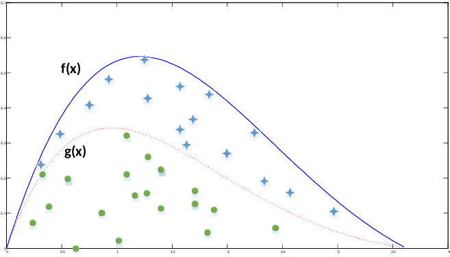

Then **for any constant c**, $\hat \theta_c = g(X) + c^*(f(Y) - \mu)$ is also an unbiased estimator of $\theta$.

$$ 𝑉𝑎𝑟(𝜃̂_c)=𝑉𝑎𝑟(𝑔(𝑋))+𝑐^2𝑉𝑎𝑟(𝑓(𝑋))+2c*𝐶𝑜𝑣(𝑔(𝑋),𝑓(𝑋)) $$

is a quadratic function of c. It is minimized at $c=c^*$, where

$$ c^* = \frac{𝐶𝑜𝑣(𝑔(𝑋),𝑓(𝑋))}{𝑉𝑎𝑟(𝑓(𝑋))} $$

and minimum variance is

$$ 𝑉𝑎𝑟(𝜃̂_{c^*}) = Var(g(X)) - \frac{[𝐶𝑜𝑣(𝑔(𝑋),𝑓(𝑋))]^2}{𝑉𝑎𝑟(𝑓(𝑋))} $$

The random variable f(X) is called a control variate for the estimator g(X).

From previous equation we can see that Var(g(X)) is reduced by $\frac{[𝐶𝑜𝑣(𝑔(𝑋),𝑓(𝑋))]^2}{𝑉𝑎𝑟(𝑓(𝑋))}$

Hence the percent reduction in variance is

$$ 100*\frac{[𝐶𝑜𝑣(𝑔(𝑋),𝑓(𝑋))]^2}{𝑉𝑎𝑟(𝑓(𝑋))Var(g(X))} = 100[𝐶𝑜𝑟(𝑔(𝑋),𝑓(𝑋))]^2 $$

To compute the constant c*, we need Cov(g(X), f(X)) and Var(f(X)), but these parameters can be estimated if necessary, from a preliminary Monte Carlo experiment.

so the higher the magnitude of correlation the higher is the reduction.

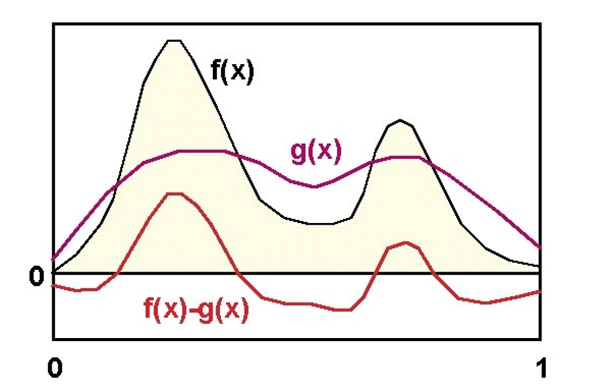

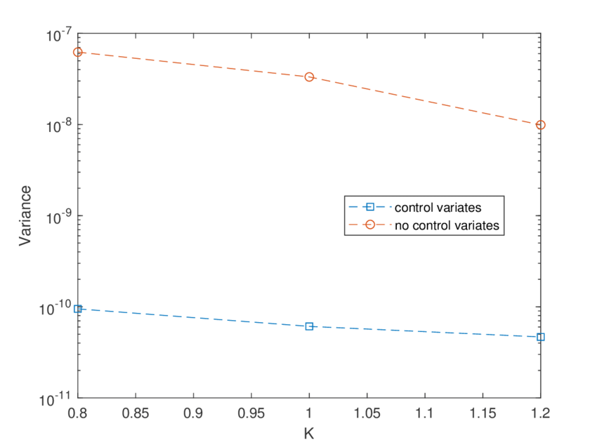

## Q5)

Use Monte Carlo integration with control variates to estimate

$$ I = \int_0^1 \frac{1}{1+x} dx $$

### That means that our g(X) function is $ \frac{1}{1+x}$. Then, we should find another function f(X), that should be correlated (similar to) g(X) function. $f(X) = 1+x$ may be correlated with g(X), because it is similar with g(X). Thus, we choose f(X) as $1+x$.

### Let first find normal estimate of the integral using simple monte carlo integration.

```r
#define parameters
n <- 10^5
a <- 0; b <- 1
x <- runif(n,a,b)

#define f(X)

g <- function(x) 1/(1+x)

# estimate g(X.bar)*(b-a)

estimate <- mean(sapply(x,g)) * (b-a)
estimate
```

0.69366882430327

```r
var.estimate <- var(sapply(x,g))
var.estimate <- mean(sapply(x,g)^2) - (mean(sapply(x, g)))^2
var.estimate
```

0.0196494401608266

## Then, use control variates

$$ 1)\ c^* = \frac{𝐶𝑜𝑣(𝑔(𝑋),𝑓(𝑋))}{𝑉𝑎𝑟(𝑓(𝑋))} $$$$ 2)\ \hat \theta_c = g(X) + c^*(f(Y) - \theta) $$

where $\theta$ is the real value of the integral and we can find it using integrate function in R.

$$ 3)\ 𝑉𝑎𝑟(𝜃̂_{c^*}) = Var(g(X)) - \frac{[𝐶𝑜𝑣(𝑔(𝑋),𝑓(𝑋))]^2}{𝑉𝑎𝑟(𝑓(𝑋))} $$

```r
#define parameters
n <- 10^4
a <- 0; b <- 1
x <- runif(n,a,b)

#define f(X) and g(X)

g.cont <- function(x) 1/(1+x)
f.cont <- function(x) 1+x


# est of c*

cor(g.cont(x),f.cont(x)) # correlation is high, we satisfy the correlation between f and g.

c_star <- -cov(g.cont(x),f.cont(x)) / var(f.cont(x))
c_star


estimate_cont = mean(g.cont(x) + c_star * (f.cont(x) - (1/(b-a))*integrate(f.cont, a, b)$value))*(b-a)

cat("Estimate using control variates is", estimate_cont)
```

-0.984273597029026

0.475615028070145

```
Estimate using control variates is 0.69282
```

```r
var.cont.estimate <- var(g.cont(x) + c_star * (f.cont(x) - integrate(f.cont, a, b)$value))
var.cont.estimate
```

0.000599585475910992

```r
result <- matrix(c(estimate,estimate_cont, var.estimate, var.cont.estimate),nrow=2,
                  dimnames = list(c("classical approach","control variates"),
                                  c("estimated mean","variance")))
result
```

|  | estimated mean | variance |
| --- | --- | --- |
| classical approach | 0.6936688 | 0.0196494402 |
| control variates | 0.6928200 | 0.0005995855 |

## The variance was significantly reduced after using the control variates technique. Then, let calculate % variance reduction.

```r
var_reduction = 100 * ((var.estimate - var.cont.estimate ) / var.estimate)

cat("The control variates approach achived",round(var_reduction,2), "%", "reduction in variance.")
```

[output not shown]